# act_report

This project is about wrangling data from Twitter account "WeRateDogs" and analyzing the wrangled data. In this project, I analyzed the data from archive of Twitter account, tweet image predictions, and additional data from Twitter's JSON data. Since dog has four stages (doggo, puppo, pupper, floofer) according to WeRateDogs, I divided the final data into four groups and investigated the characteristics for each dog stage. First, I am interested in which dog stage gets the highest and the lowest average rating. I first calculated the average rating for each tweet because some tweets have posted multiple dogs while others have one, and it is hard to compare them together. Then I calculated the mean rating for each dog stage and created a bar chart.

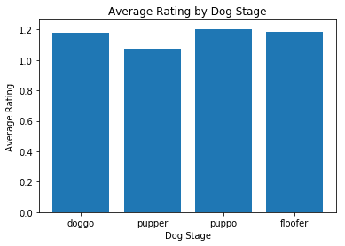

From the bar chart above, we can conclude that when a dog is in "puppo" stage, it gets the highest average rating of 1.20. When a dog is in "pupper" stage, it gets the lowest average rating of 1.07.

Next, I wanted to investigate if the dog stage that gets the highest rating have the most favorite counts. I calculated average favorite counts for each dog stage and created a bar chart.

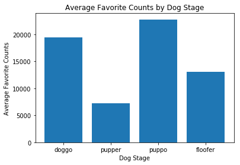

The result matches my thought. "puppo" stage, which gets the highest average rating, has the highest average favorite counts. "pupper" stage, which gets the lowest average rating, has the lowest average favorite counts.

Finally, I was curious about how precise is our neural network to predict dog breeds. I checked each prediction and saw if it predicted correctly on the first try, or the second try, or the third. The result is convicing. 87.5% of predictions for dog breed is correct for the first time. 8.8% predictions for dog breed is correct for the second time. 3.7% predictions for dog breed is correct for the third time. It means that the neural network has a high prediction rate.